# Economic_Sentiment_Analysis

Author

Diveesha Vanchireddy

Published

March 19, 2026

## Data Setup:

1. How to pull bds2022_st_cty (now bds2023_st_cty) from pubdata? - got it.
2. How to merge BDS and CHRR using FIPS as composite key? - paste st X county but CHHR also has a FIPS code already so just going ot use that.
3. How to align years between BDS and CHRR? average CHHR 2022 = 2019-2020 surveyed data.
4. What about 2019, 2020, 2021 CHRR files for panel?

## EDA tasks listed:

1. Descriptive stats of all variables (mean, median, sd, min, max)
2. Correlation matrix of all variables to see initial relationships
3. Time series plots of BDS reallocation rate and CHRR health outcomes over time
4. Scatter plots of reallocation rate vs mental health and physical health outcomes
5. Statistical tests comparing coefficients of economic distress in mental vs physical health models
6. Analysis of BDS pandemic-era volatility (2019–2022) to see if there were significant changes during COVID years
7. Robustness checks using other BDS measures of job volatility (job creation rate, job destruction rate, etc.) to see if results hold across different specifications

# Main analytical questions to answer:

1. Mental unhealthy days vs physically unhealthy days — WHICH VARIABLE TO FOCUS ON? 2)Is mental health more associated with economic distress than physical health? Do a stat test comparing coefficient magnitudes
2. Correlation between insured vs uninsured adults in terms of health impacts?
3. Does reallocation rate work as the main explanatory variable?
4. Reallocation rate = default explanatory variable

# Next steps:

1. Aligning CHRR data.

```r
library(pubdata)
library(tidyverse)
get_merged_cross_section <- function(bds_year, chrr_offset = 2) {
  chrr_year <- as.character(bds_year + chrr_offset)
  chrr_raw <- pubdata::get("chrr", chrr_year)
  my_vars <- c(
    "v001_rawvalue", "v036_rawvalue", "v042_rawvalue", "v145_rawvalue",
    "v024_rawvalue", "v023_rawvalue", "v082_rawvalue", "v085_rawvalue",
    "v009_rawvalue", "v011_rawvalue"
  )

  chrr_wi <- chrr_raw |>
    filter(statecode == "55", countycode != "000", variable %in% my_vars) |>
    select(fipscode, county, variable, value) |>
    pivot_wider(names_from = variable, values_from = value) |>
    rename(
      premature_death = v001_rawvalue,
      phys_unhealthy = v036_rawvalue,
      mental_unhealthy = v042_rawvalue,
      freq_mental_distress = v145_rawvalue,
      child_poverty = v024_rawvalue,
      unemployed = v023_rawvalue,
      single_parent = v082_rawvalue,
      uninsured = v085_rawvalue,
      smokers = v009_rawvalue,
      obese = v011_rawvalue
    )

 bds_slice <- bds_wi |>
    filter(year == bds_year) |>
    select(fipscode, reallocation_rate, job_creation_rate, job_destruction_rate,
           net_job_creation_rate, estabs_entry_rate, estabs_exit_rate)
 result <- inner_join(chrr_wi, bds_slice, by = "fipscode") |>
    mutate(bds_year = bds_year, chrr_release = as.integer(chrr_year))
  return(result)

}
```

```r
bds_raw <- pubdata::get("bds", "2022_st_cty") # swtich to 2023_st_cty becuase more recent and pandemic era data.
bds_wi <- bds_raw |>
  filter(st == "55") |>
  mutate(
    fipscode = paste0(st, cty),
    year = as.integer(year),
    across(
      c(job_creation_rate, job_destruction_rate, net_job_creation_rate,
        reallocation_rate, estabs_entry_rate, estabs_exit_rate),
      ~as.numeric(replace(.x, .x == "X", NA))
    )
  )
```

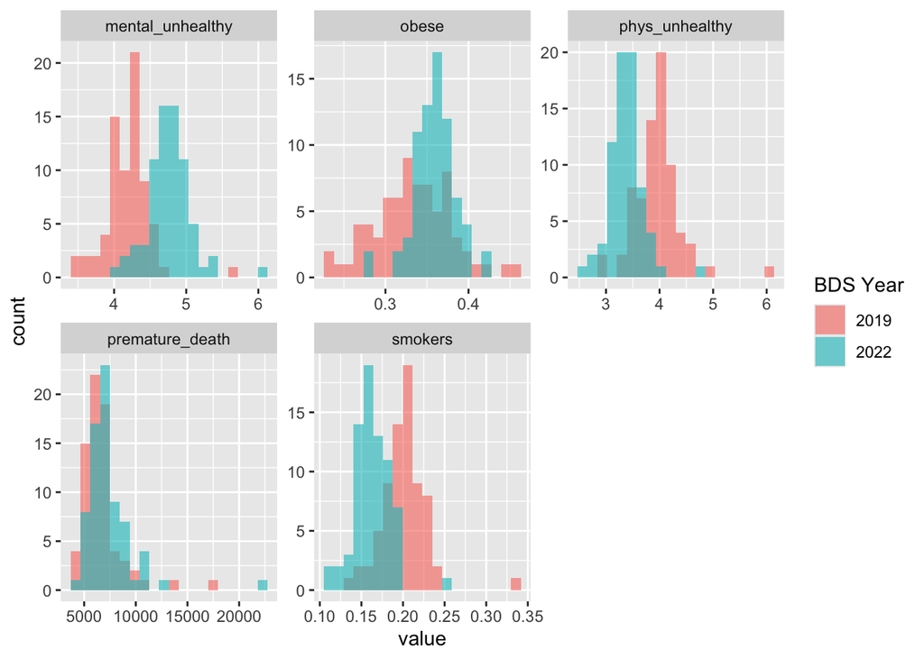

```r
# Pre-COVID cross-section
pre_covid <- get_merged_cross_section(2019)

# Post-COVID cross-section
post_covid <- get_merged_cross_section(2022)

#get both
both <- bind_rows(pre_covid, post_covid)
both |>
  select(fipscode, bds_year, premature_death:obese) |>
  pivot_longer(premature_death:obese) |>
  ggplot(aes(x = value, fill = factor(bds_year))) +
  geom_histogram(bins = 20, alpha = 0.6, position = "identity") +
  facet_wrap(~name, scales = "free") +
  labs(fill = "BDS Year")
```

```r
# Check what you got
cat("Pre-COVID:", nrow(pre_covid), "counties\n")
```

```
Pre-COVID: 72 counties
```

```r
cat("Post-COVID:", nrow(post_covid), "counties\n")
```

```
Post-COVID: 72 counties
```

## Performing EDA on the merged dataset:

- We have successfully merged the BDS and CHRR datasets using FIPS codes, creating a comprehensive dataset for analysis. ## getting descriptive stats for all variables in this one cross-section dataset:

```r
desc_stats <- both |>
  select(bds_year, premature_death:obese, reallocation_rate,
         job_creation_rate, job_destruction_rate, net_job_creation_rate) |>
  pivot_longer(-bds_year, names_to = "variable", values_to = "value") |>
  group_by(bds_year, variable) |>
  summarise(
    n = sum(!is.na(value)),
    mean = round(mean(value, na.rm = TRUE), 3),
    sd = round(sd(value, na.rm = TRUE), 3),
    min = round(min(value, na.rm = TRUE), 3),
    p5 = round(quantile(value, 0.05, na.rm = TRUE), 3),
    p25 = round(quantile(value, 0.25, na.rm = TRUE), 3),
    median = round(median(value, na.rm = TRUE), 3),
    p75 = round(quantile(value, 0.75, na.rm = TRUE), 3),
    p95 = round(quantile(value, 0.95, na.rm = TRUE), 3),
    max = round(max(value, na.rm = TRUE), 3),
    na_count = sum(is.na(value)),
    .groups = "drop"
  ) |>
  arrange(variable, bds_year)

desc_stats |> print(n = 40)
```

```
# A tibble: 18 × 13
   bds_year variable       n     mean      sd      min       p5      p25  median
      <dbl> <chr>      <int>    <dbl>   <dbl>    <dbl>    <dbl>    <dbl>   <dbl>
 1     2019 job_creat…    72   10.0   3.03e+0    1.38     6.23     8.54  9.92e+0
 2     2022 job_creat…    72   13.4   2.81e+0    1.85    10.1     11.9   1.34e+1
 3     2019 job_destr…    72   10.6   3.66e+0    1.28     6.82     8.58  9.90e+0
 4     2022 job_destr…    72   12.6   7.74e+0    6.82     8.03     9.48  1.10e+1
 5     2019 mental_un…    72    4.19  3.07e-1    3.46     3.73     4.01  4.22e+0
 6     2022 mental_un…    72    4.76  3.06e-1    3.98     4.28     4.61  4.75e+0
 7     2019 net_job_c…    72   -0.54  3.51e+0  -11.5     -7.77    -1.90  1.6 e-2
 8     2022 net_job_c…    72    0.781 9.18e+0  -68.0     -7.13     0.49  2.38e+0
 9     2019 obese         72    0.333 4.7 e-2    0.232    0.259    0.306 3.3 e-1
10     2022 obese         72    0.359 2.5 e-2    0.28     0.321    0.344 3.6 e-1
11     2019 phys_unhe…    72    3.95  4.34e-1    2.94     3.37     3.74  3.99e+0
12     2022 phys_unhe…    72    3.38  3.15e-1    2.56     2.93     3.20  3.35e+0
13     2019 premature…    72 6617.    1.99e+3 4163.    4616.    5491.    6.15e+3
14     2022 premature…    72 7365.    2.41e+3 4431.    4794.    6205.    6.99e+3
15     2019 reallocat…    72   18.2   5.31e+0    2.57    12.3     15.6   1.78e+1
16     2022 reallocat…    72   21.5   4.91e+0    3.70    15.3     18.7   2.11e+1
17     2019 smokers       72    0.201 2.7 e-2    0.141    0.158    0.187 2.01e-1
18     2022 smokers       72    0.163 2.2 e-2    0.111    0.131    0.15  1.64e-1
# ℹ 4 more variables: p75 <dbl>, p95 <dbl>, max <dbl>, na_count <int>
```

## Correlation matrix of all variables to see initial relationships:

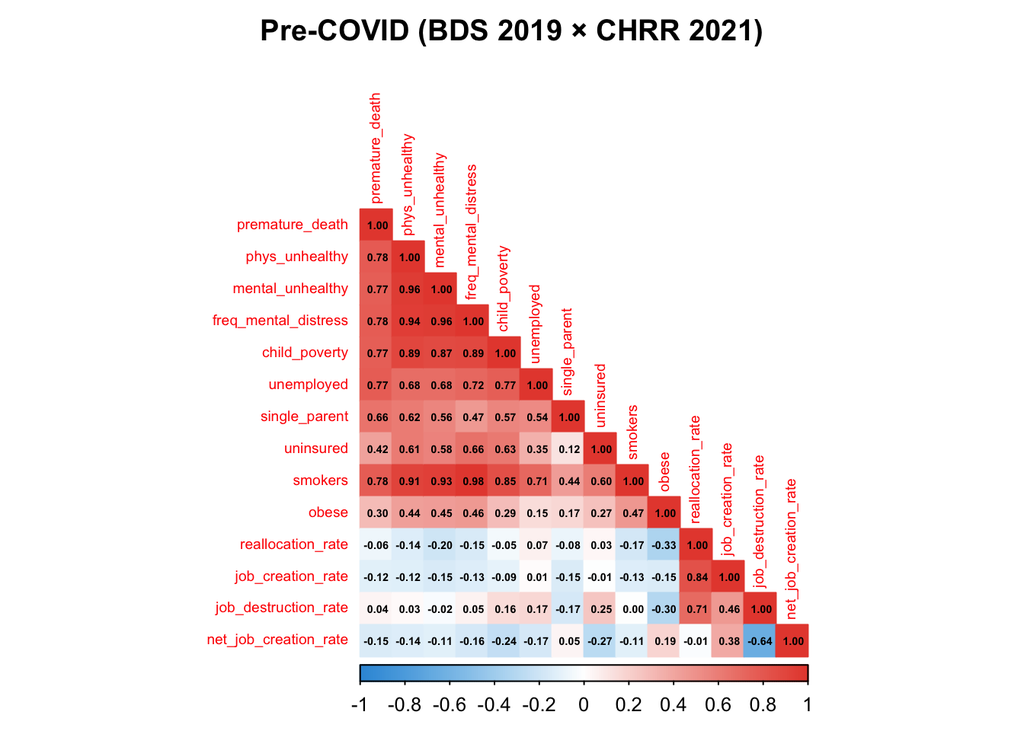

```r
library(corrplot)
# All CHRR + BDS variables for pre-covid
cor_vars <- c("premature_death", "phys_unhealthy", "mental_unhealthy",
              "freq_mental_distress", "child_poverty", "unemployed",
              "single_parent", "uninsured", "smokers", "obese",
              "reallocation_rate", "job_creation_rate", "job_destruction_rate",
              "net_job_creation_rate")

cor_pre <- pre_covid |>
  select(all_of(cor_vars)) |>
  cor(use = "pairwise.complete.obs")

cor_post <- post_covid |>
  select(all_of(cor_vars)) |>
  cor(use = "pairwise.complete.obs")

# Plot pre-covid
corrplot(cor_pre, method = "color", type = "lower",
         addCoef.col = "black", number.cex = 0.45, tl.cex = 0.6,
         col = colorRampPalette(c("#3498DB", "white", "#E74C3C"))(200),
         title = "Pre-COVID (BDS 2019 × CHRR 2021)", mar = c(0,0,2,0))
```

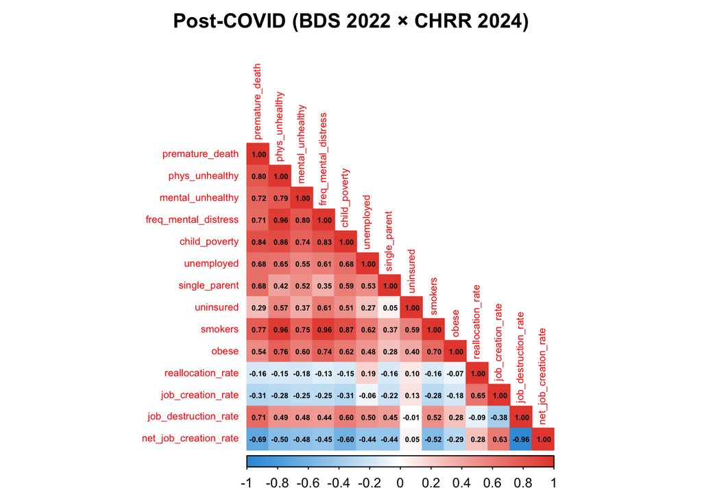

```r
# Plot post-covid
corrplot(cor_post, method = "color", type = "lower",
         addCoef.col = "black", number.cex = 0.45, tl.cex = 0.6,
         col = colorRampPalette(c("#3498DB", "white", "#E74C3C"))(200),
         title = "Post-COVID (BDS 2022 × CHRR 2024)", mar = c(0,0,2,0))
```

## Scatter plots of reallocation rate vs mental health and physical health outcomes:

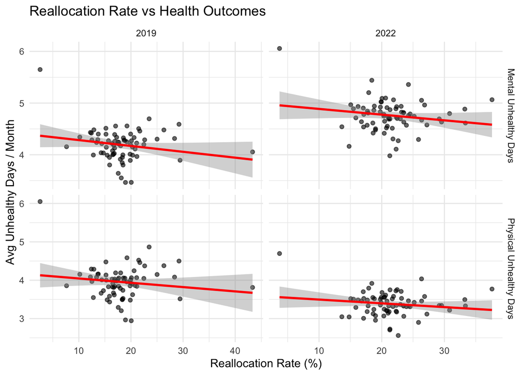

```r
# Reallocation vs both health outcomes, both periods
both |>
  pivot_longer(c(mental_unhealthy, phys_unhealthy),
               names_to = "outcome", values_to = "days") |>
  mutate(outcome = ifelse(outcome == "mental_unhealthy",
                          "Mental Unhealthy Days", "Physical Unhealthy Days")) |>
  ggplot(aes(x = reallocation_rate, y = days)) +
  geom_point(alpha = 0.6) +
  geom_smooth(method = "lm", se = TRUE, color = "red") +
  facet_grid(outcome ~ bds_year, scales = "free") +
  labs(title = "Reallocation Rate vs Health Outcomes",
       x = "Reallocation Rate (%)", y = "Avg Unhealthy Days / Month") +
  theme_minimal()
```

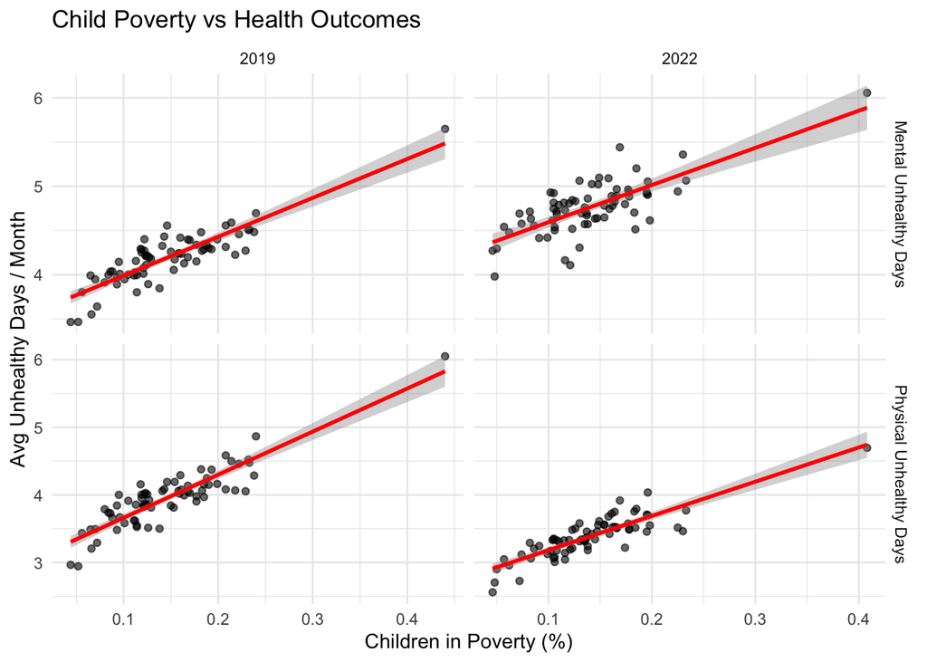

```r
# Also do child poverty since it's your strongest predictor
both |>
  pivot_longer(c(mental_unhealthy, phys_unhealthy),
               names_to = "outcome", values_to = "days") |>
  mutate(outcome = ifelse(outcome == "mental_unhealthy",
                          "Mental Unhealthy Days", "Physical Unhealthy Days")) |>
  ggplot(aes(x = child_poverty, y = days)) +
  geom_point(alpha = 0.6) +
  geom_smooth(method = "lm", se = TRUE, color = "red") +
  facet_grid(outcome ~ bds_year, scales = "free") +
  labs(title = "Child Poverty vs Health Outcomes",
       x = "Children in Poverty (%)", y = "Avg Unhealthy Days / Month") +
  theme_minimal()
```

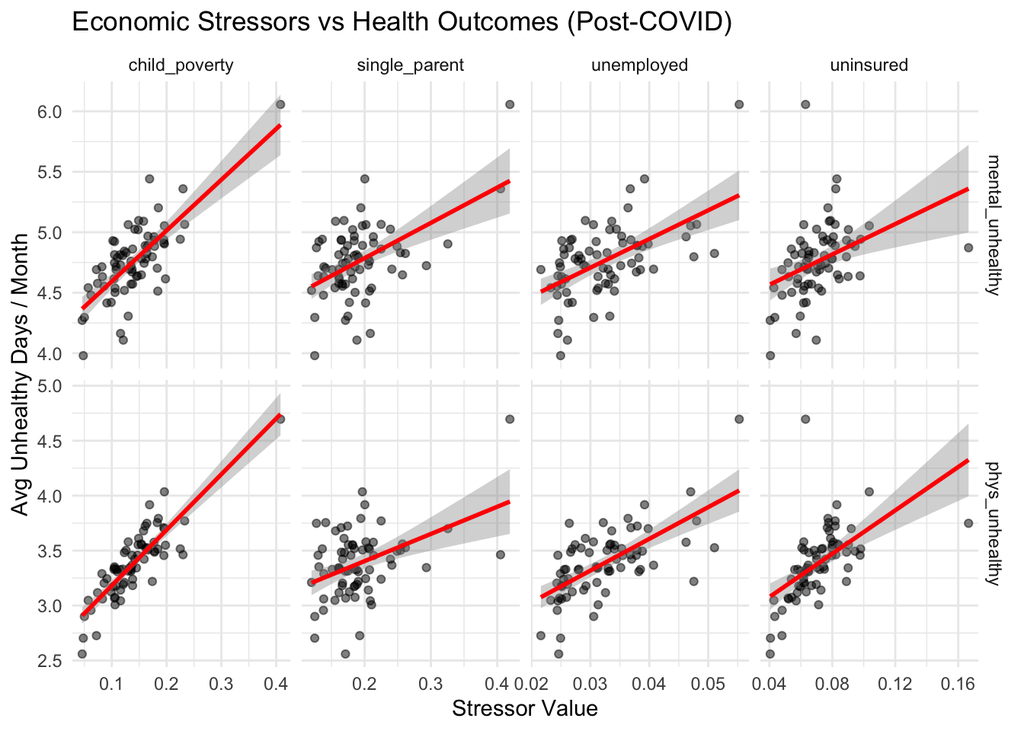

```r
# All 4 economic stressors vs both outcomes — post-covid only to keep it readable
post_covid |>
  pivot_longer(c(child_poverty, unemployed, single_parent, uninsured),
               names_to = "stressor", values_to = "stressor_val") |>
  pivot_longer(c(mental_unhealthy, phys_unhealthy),
               names_to = "outcome", values_to = "days") |>
  ggplot(aes(x = stressor_val, y = days)) +
  geom_point(alpha = 0.5, size = 1.5) +
  geom_smooth(method = "lm", se = TRUE, color = "red") +
  facet_grid(outcome ~ stressor, scales = "free") +
  labs(title = "Economic Stressors vs Health Outcomes (Post-COVID)",
       x = "Stressor Value", y = "Avg Unhealthy Days / Month") +
  theme_minimal()
```

## Statistical tests comparing coefficients of economic distress in mental vs physical health models:

```r
library(broom)
install.packages("huxtable")
library(huxtable)
# Run economic-only models for both outcomes, both periods
models <- list(
  pre_mental = lm(mental_unhealthy ~ child_poverty + unemployed + single_parent + uninsured, data = pre_covid),
  pre_phys = lm(phys_unhealthy ~ child_poverty + unemployed + single_parent + uninsured, data = pre_covid),
  post_mental = lm(mental_unhealthy ~ child_poverty + unemployed + single_parent + uninsured, data = post_covid),
  post_phys = lm(phys_unhealthy ~ child_poverty + unemployed + single_parent + uninsured, data = post_covid)
)

huxreg(
  "Pre: Mental" = models$pre_mental,
  "Pre: Physical" = models$pre_phys,
  "Post: Mental" = models$post_mental,
  "Post: Physical" = models$post_phys,
  statistics = c("R squared" = "r.squared", "Adj. R squared" = "adj.r.squared", "N" = "nobs")
)
```

|  | Pre: Mental | Pre: Physical | Post: Mental | Post: Physical |
| --- | --- | --- | --- | --- |
| (Intercept) | 3.373 *** | 2.704 *** | 3.997 *** | 2.466 *** |
|  | (0.117) | (0.141) | (0.164) | (0.117) |
| child_poverty | 3.492 *** | 4.756 *** | 3.359 *** | 4.292 *** |
|  | (0.634) | (0.768) | (0.808) | (0.579) |
| unemployed | 1.468 | -0.390 | 3.294 | 7.735 * |
|  | (3.194) | (3.869) | (4.847) | (3.471) |
| single_parent | 0.641 | 1.515 ** | 0.697 | -0.642 |
|  | (0.375) | (0.455) | (0.623) | (0.446) |
| uninsured | 1.749 | 3.744 * | 0.774 | 2.689 * |
|  | (1.267) | (1.534) | (1.705) | (1.221) |
| R squared | 0.771 | 0.831 | 0.558 | 0.787 |
| Adj. R squared | 0.757 | 0.821 | 0.532 | 0.774 |
| N | 72 | 72 | 72 | 72 |
| *** p < 0.001; ** p < 0.01; * p < 0.05. |  |  |  |  |

```r
# Compare coefficients side by side
coef_comparison <- map_dfr(names(models), function(name) {
  tidy(models[[name]]) |>
    mutate(model = name)
}) |>
  separate(model, into = c("period", "outcome"), sep = "_") |>
  select(period, outcome, term, estimate, std.error, p.value) |>
  filter(term != "(Intercept)")

coef_comparison |>
  pivot_wider(names_from = outcome, values_from = c(estimate, std.error, p.value)) |>
  mutate(
    coef_diff = estimate_mental - estimate_phys,
    mental_bigger = abs(estimate_mental) > abs(estimate_phys)
  ) |>
  print()
```

```
# A tibble: 8 × 10
  period term      estimate_mental estimate_phys std.error_mental std.error_phys
  <chr>  <chr>               <dbl>         <dbl>            <dbl>          <dbl>
1 pre    child_po…           3.49          4.76             0.634          0.768
2 pre    unemploy…           1.47         -0.390            3.19           3.87
3 pre    single_p…           0.641         1.52             0.375          0.455
4 pre    uninsured           1.75          3.74             1.27           1.53
5 post   child_po…           3.36          4.29             0.808          0.579
6 post   unemploy…           3.29          7.74             4.85           3.47
7 post   single_p…           0.697        -0.642            0.623          0.446
8 post   uninsured           0.774         2.69             1.70           1.22
# ℹ 4 more variables: p.value_mental <dbl>, p.value_phys <dbl>,
#   coef_diff <dbl>, mental_bigger <lgl>
```

```r
# Bootstrap test for child_poverty coefficient difference
set.seed(42)
n_boot <- 2000

boot_pre <- replicate(n_boot, {
  idx <- sample(nrow(pre_covid), replace = TRUE)
  d <- pre_covid[idx, ]
  m_m <- lm(mental_unhealthy ~ child_poverty + unemployed + single_parent + uninsured, data = d)
  m_p <- lm(phys_unhealthy ~ child_poverty + unemployed + single_parent + uninsured, data = d)
  coef(m_m)["child_poverty"] - coef(m_p)["child_poverty"]
})

boot_post <- replicate(n_boot, {
  idx <- sample(nrow(post_covid), replace = TRUE)
  d <- post_covid[idx, ]
  m_m <- lm(mental_unhealthy ~ child_poverty + unemployed + single_parent + uninsured, data = d)
  m_p <- lm(phys_unhealthy ~ child_poverty + unemployed + single_parent + uninsured, data = d)
  coef(m_m)["child_poverty"] - coef(m_p)["child_poverty"]
})

cat("--- Child Poverty: Mental vs Physical Coefficient ---\n\n")
```

```
--- Child Poverty: Mental vs Physical Coefficient ---
```

```r
cat("Pre-COVID:\n")
```

```
Pre-COVID:
```

```r
cat("  Mean diff:", round(mean(boot_pre), 4), "\n")
```

```
  Mean diff: -1.177
```

```r
cat("  95% CI: [", round(quantile(boot_pre, 0.025), 4), ",", round(quantile(boot_pre, 0.975), 4), "]\n")
```

```
  95% CI: [ -2.2088 , -0.1043 ]
```

```r
cat("  Significant:", !between(0, quantile(boot_pre, 0.025), quantile(boot_pre, 0.975)), "\n\n")
```

```
  Significant: TRUE
```

```r
cat("Post-COVID:\n")
```

```
Post-COVID:
```

```r
cat("  Mean diff:", round(mean(boot_post), 4), "\n")
```

```
  Mean diff: -1.0125
```

```r
cat("  95% CI: [", round(quantile(boot_post, 0.025), 4), ",", round(quantile(boot_post, 0.975), 4), "]\n")
```

```
  95% CI: [ -2.6764 , 0.3204 ]
```

```r
cat("  Significant:", !between(0, quantile(boot_post, 0.025), quantile(boot_post, 0.975)), "\n")
```

```
  Significant: FALSE
```

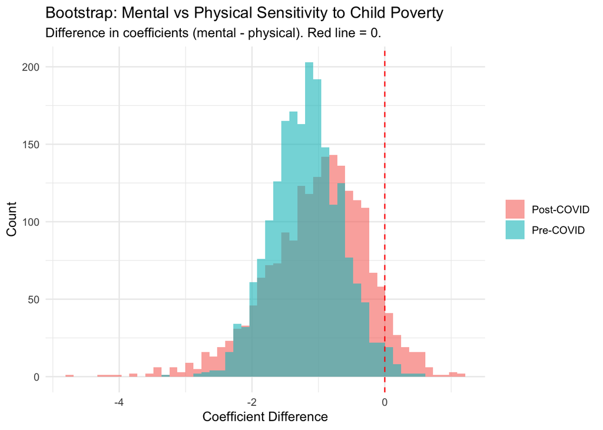

```r
# Plot both bootstrap distributions
bind_rows(
  tibble(diff = boot_pre, period = "Pre-COVID"),
  tibble(diff = boot_post, period = "Post-COVID")
) |>
  ggplot(aes(x = diff, fill = period)) +
  geom_histogram(bins = 50, alpha = 0.6, position = "identity") +
  geom_vline(xintercept = 0, linetype = "dashed", color = "red") +
  labs(title = "Bootstrap: Mental vs Physical Sensitivity to Child Poverty",
       subtitle = "Difference in coefficients (mental - physical). Red line = 0.",
       x = "Coefficient Difference", y = "Count", fill = NULL) +
  theme_minimal()
```

## Q7Robustness checks using other BDS measures of job volatility (job creation rate, job destruction rate, etc.) to see if results hold across different specifications

```r
# Run mental health model with each BDS variable separately, both periods
bds_measures <- c("reallocation_rate", "job_creation_rate", "job_destruction_rate",
                  "net_job_creation_rate", "estabs_entry_rate", "estabs_exit_rate")

robustness <- map_dfr(bds_measures, function(bds_var) {

  formula_str <- paste("mental_unhealthy ~ child_poverty + unemployed + single_parent + uninsured +", bds_var)
  f <- as.formula(formula_str)

  m_pre <- lm(f, data = pre_covid)
  m_post <- lm(f, data = post_covid)

  bind_rows(
    tidy(m_pre) |> filter(term == bds_var) |>
      mutate(period = "pre_covid", r_squared = summary(m_pre)$r.squared),
    tidy(m_post) |> filter(term == bds_var) |>
      mutate(period = "post_covid", r_squared = summary(m_post)$r.squared)
  )
}) |>
  select(period, term, estimate, std.error, p.value, r_squared) |>
  mutate(
    significant = p.value < 0.05,
    across(c(estimate, std.error, p.value, r_squared), ~round(.x, 4))
  )

robustness |> print(n = 20)
```

```
# A tibble: 12 × 7
   period     term              estimate std.error p.value r_squared significant
   <chr>      <chr>                <dbl>     <dbl>   <dbl>     <dbl> <lgl>
 1 pre_covid  reallocation_rate  -0.0096    0.0033  0.0047     0.797 TRUE
 2 post_covid reallocation_rate  -0.0074    0.0058  0.209      0.569 FALSE
 3 pre_covid  job_creation_rate  -0.0074    0.0061  0.225      0.776 FALSE
 4 post_covid job_creation_rate  -0.007     0.0103  0.500      0.561 FALSE
 5 pre_covid  job_destruction_…  -0.0145    0.0051  0.006      0.796 TRUE
 6 post_covid job_destruction_…   0.0025    0.0046  0.584      0.560 FALSE
 7 pre_covid  net_job_creation…   0.009     0.0054  0.098      0.780 FALSE
 8 post_covid net_job_creation…  -0.0029    0.004   0.464      0.562 FALSE
 9 pre_covid  estabs_entry_rate   0.0034    0.0122  0.782      0.676 FALSE
10 post_covid estabs_entry_rate  -0.0292    0.0182  0.113      0.440 FALSE
11 pre_covid  estabs_exit_rate   -0.0105    0.0154  0.500      0.678 FALSE
12 post_covid estabs_exit_rate    0.0216    0.0202  0.291      0.566 FALSE
```

```r
# Same for physical health
robustness_phys <- map_dfr(bds_measures, function(bds_var) {

  formula_str <- paste("phys_unhealthy ~ child_poverty + unemployed + single_parent + uninsured +", bds_var)
  f <- as.formula(formula_str)

  m_pre <- lm(f, data = pre_covid)
  m_post <- lm(f, data = post_covid)

  bind_rows(
    tidy(m_pre) |> filter(term == bds_var) |>
      mutate(period = "pre_covid", r_squared = summary(m_pre)$r.squared, outcome = "physical"),
    tidy(m_post) |> filter(term == bds_var) |>
      mutate(period = "post_covid", r_squared = summary(m_post)$r.squared, outcome = "physical")
  )
})

robustness_all <- bind_rows(
  robustness |> mutate(outcome = "mental"),
  robustness_phys
) |>
  select(period, outcome, term, estimate, p.value, r_squared, significant) |>
  arrange(term, period, outcome)

robustness_all |> print(n = 30)
```

```
# A tibble: 24 × 7
   period     outcome  term               estimate p.value r_squared significant
   <chr>      <chr>    <chr>                 <dbl>   <dbl>     <dbl> <lgl>
 1 post_covid mental   estabs_entry_rate  -0.0292  0.113       0.440 FALSE
 2 post_covid physical estabs_entry_rate  -0.0415  0.00109     0.767 NA
 3 pre_covid  mental   estabs_entry_rate   0.0034  0.782       0.676 FALSE
 4 pre_covid  physical estabs_entry_rate   0.00932 0.525       0.763 NA
 5 post_covid mental   estabs_exit_rate    0.0216  0.291       0.566 FALSE
 6 post_covid physical estabs_exit_rate   -0.00457 0.755       0.787 NA
 7 pre_covid  mental   estabs_exit_rate   -0.0105  0.500       0.678 FALSE
 8 pre_covid  physical estabs_exit_rate   -0.00582 0.754       0.762 NA
 9 post_covid mental   job_creation_rate  -0.007   0.500       0.561 FALSE
10 post_covid physical job_creation_rate  -0.0140  0.0573      0.798 NA
11 pre_covid  mental   job_creation_rate  -0.0074  0.225       0.776 FALSE
12 pre_covid  physical job_creation_rate  -0.00441 0.554       0.832 NA
13 post_covid mental   job_destruction_r…  0.0025  0.584       0.560 FALSE
14 post_covid physical job_destruction_r…  0.00138 0.676       0.787 NA
15 pre_covid  mental   job_destruction_r… -0.0145  0.006       0.796 TRUE
16 pre_covid  physical job_destruction_r… -0.0120  0.0650      0.840 NA
17 post_covid mental   net_job_creation_… -0.0029  0.464       0.562 FALSE
18 post_covid physical net_job_creation_… -0.00308 0.278       0.790 NA
19 pre_covid  mental   net_job_creation_…  0.009   0.098       0.780 FALSE
20 pre_covid  physical net_job_creation_…  0.00884 0.183       0.836 NA
21 post_covid mental   reallocation_rate  -0.0074  0.209       0.569 FALSE
22 post_covid physical reallocation_rate  -0.00934 0.0247      0.802 NA
23 pre_covid  mental   reallocation_rate  -0.0096  0.0047      0.797 TRUE
24 pre_covid  physical reallocation_rate  -0.00792 0.0587      0.840 NA
```

## Question 8: What about other states? Does this finding hold in the national context?

```r
# Load necessary libraries
library(pubdata)
library(dplyr)
library(tidyr)
library(arrow)
# National CHRR — all counties, all states
my_vars <- c(
  "v001_rawvalue", "v036_rawvalue", "v042_rawvalue", "v145_rawvalue",
  "v024_rawvalue", "v023_rawvalue", "v082_rawvalue", "v085_rawvalue",
  "v009_rawvalue", "v011_rawvalue"
)

chrr_national_clean <- pubdata::path("chrr", "2024") |>
  open_dataset() |>
  filter(year == 2024, countycode != "000", variable %in% my_vars) |>
  select(fipscode, variable, value) |>
  collect() |>
  pivot_wider(id_cols = fipscode, names_from = variable, values_from = value) |>
  rename(
    premature_death = v001_rawvalue,
    phys_unhealthy = v036_rawvalue,
    mental_unhealthy = v042_rawvalue,
    freq_mental_distress = v145_rawvalue,
    child_poverty = v024_rawvalue,
    unemployed = v023_rawvalue,
    single_parent = v082_rawvalue,
    uninsured = v085_rawvalue,
    smokers = v009_rawvalue,
    obese = v011_rawvalue
  )

cat("CHRR national counties:", nrow(chrr_national_clean), "\n")
```

```
CHRR national counties: 3143
```

```r
# --- BDS National ---
bds_national_clean <- bds_raw |>
  filter(year == 2022) |>
  mutate(
    fipscode = paste0(st, cty),
    reallocation_rate = as.numeric(na_if(as.character(reallocation_rate), "X"))
  ) |>
  select(fipscode, reallocation_rate)

cat("BDS national counties:", nrow(bds_national_clean), "\n")
```

```
BDS national counties: 3251
```

```r
# --- Merge ---
merged_national <- inner_join(chrr_national_clean, bds_national_clean, by = "fipscode")
cat("Merged national:", nrow(merged_national), "\n")
```

```
Merged national: 3135
```

```r
cat("NAs in reallocation:", sum(is.na(merged_national$reallocation_rate)), "\n")
```

```
NAs in reallocation: 2
```

```r
cat("NAs in mental_unhealthy:", sum(is.na(merged_national$mental_unhealthy)), "\n")
```

```
NAs in mental_unhealthy: 0
```

```r
# --- National model ---
m_national <- lm(
  mental_unhealthy ~ child_poverty + unemployed + single_parent + uninsured + reallocation_rate,
  data = merged_national
)

# --- Comparison table ---
# You need to re-create the WI models with the same spec if they don't exist yet
m_pre_wi <- lm(mental_unhealthy ~ child_poverty + unemployed + single_parent + uninsured + reallocation_rate, data = pre_covid)
m_post_wi <- lm(mental_unhealthy ~ child_poverty + unemployed + single_parent + uninsured + reallocation_rate, data = post_covid)

huxreg(
  "WI Pre-COVID" = m_pre_wi,
  "WI Post-COVID" = m_post_wi,
  "National 2022" = m_national,
  statistics = c("R squared" = "r.squared", "Adj. R squared" = "adj.r.squared", "N" = "nobs")
)
```

|  | WI Pre-COVID | WI Post-COVID | National 2022 |
| --- | --- | --- | --- |
| (Intercept) | 3.509 *** | 4.094 *** | 4.119 *** |
|  | (0.120) | (0.180) | (0.047) |
| child_poverty | 3.209 *** | 2.942 ** | 3.277 *** |
|  | (0.609) | (0.869) | (0.159) |
| unemployed | 3.233 | 6.397 | 9.991 *** |
|  | (3.088) | (5.408) | (0.833) |
| single_parent | 0.579 | 0.613 | 0.077 |
|  | (0.357) | (0.624) | (0.116) |
| uninsured | 2.107 | 1.276 | 0.102 |
|  | (1.207) | (1.742) | (0.187) |
| reallocation_rate | -0.010 ** | -0.007 | 0.003 * |
|  | (0.003) | (0.006) | (0.002) |
| R squared | 0.797 | 0.569 | 0.339 |
| Adj. R squared | 0.781 | 0.536 | 0.338 |
| N | 72 | 72 | 3133 |
| *** p < 0.001; ** p < 0.01; * p < 0.05. |  |  |  |